# Ohio Apprenticeship Program Descriptive Statistics

Sean Franco

2025-08-02

**Name:** Task_3_Descriptive_Stats.rmd  
**Purpose:** To clean, and perform exploratory data analysis on Ohio’s registered apprentice data.  
**Author:** Sean Franco  
**Date Created:** 2025_07_23  
**Inputs:** 4 Files: ‘oh_appr_person.csv’;  
‘oh_appr_program.csv’;  
‘2-6 digit_2022_Codes.xlsx’;  
‘historical-cpi-u-202506.xlsx’ Downloaded from https://www.bls.gov/cpi/tables/supplemental-files/ ‘Historical CPI-U, June 2025 (database) (XLSX)’  
**Outputs:** Task_3_Descriptive_Stats.html  
**Notes:** 3/3 Interview file submission.

The code chunk below loads the 2 apprentice project datasets, and loads necessary libraries for R Markdown.

```r
#install.packages('devtools')
#devtools::install_github("physicsland/ezids")
#library(devtools)

library(ezids)

data_wd <- "C:/Users/18045/Documents/R/OSU_Project/Data"
file_wd <- "C:/Users/18045/Documents/R/OSU_Project"

setwd(file_wd)
#install.packages('pacman')
library('pacman')
pacman::p_load(ggplot2, xtable, dplyr,  readxl, gridExtra, xtable,
               readr, car, xtable, knitr, kableExtra, forcats, lubridate,
               maps, mapdata, usmap, sf, tigris, shiny)

#LoadData----

appr_person_df <- read.csv(file.path(data_wd, 'oh_appr_person.csv')) #participant data

appr_prog_df <- read.csv(file.path(data_wd, 'oh_appr_program.csv')) #program data

naics_df <- read_excel(file.path(data_wd, "2-6 digit_2022_Codes.xlsx")) #download NAICS codes here: https://www.census.gov/naics/?48967 selecting the 2-6 digit 2022 Code File [XLSX, 81KB]
naics_df <- naics_df[-1, -c(1, 4,5)] #remove first row, and 1, 4, 5 columns
names(naics_df) <- trimws(names(naics_df))

cpi_bls <- read_excel(file.path(data_wd, 'historical-cpi-u-202506.xlsx'),
                                  skip = 3,
                                  sheet = 'All items index averages') #get CPI to convert to the first half of 2025 dollars
cpi_bls <- cpi_bls[-c(1,2),-1]
```

# **Data Cleaning**

## Demographic Coding

This code chunk applies demographic levels for factor variables such as Race, Gender, Ethnicity, Veteran Status, Disabled Status, and Education level.

```r
#applying dictionary terms to demographic information

appr_person_df <- appr_person_df %>%
      mutate(across(c(Race, Gender, Ethnicity), ~ na_if(., "")))%>%
      mutate(
        education = case_when(education == 1 ~ '8th grade or less',
                                    education == 1 ~ '8th grade or less',
                                    education == 2 ~ '9th to 12th grade',
                                    education == 3 ~ 'GED',
                                    education == 4 ~ 'High school or greater',
                                    education == 5 ~ 'Unknown',
                                    education == 6 ~ 'Post-secondary or technical training' ),

            Ethnicity = case_when(Ethnicity == 'H' ~ 'Hispanic',
                                  Ethnicity == 'N' ~ 'Not Hispanic',
                                  Ethnicity == 'NP' ~ 'Not Provided'),

            apprStatus = case_when(apprStatus == 'CA' ~ 'Cancelled',
                                  apprStatus == 'CO' ~ 'Completed',
                                  apprStatus == 'RE' ~ 'Registered',
                                  apprStatus == 'RI' ~ 'Suspended/Reinstated/Transferred',
                                  apprStatus == 'SU' ~ 'Suspended/Reinstated/Transferred',
                                  apprStatus == 'TR' ~ 'Suspended/Reinstated/Transferred'),

            Gender = case_when(Gender == "M"~ 'Male',
                               Gender == 'F' ~ 'Female'),

            Disabled = case_when(Disabled  == "Y"~ 'Yes',
                               Disabled  == 'N' ~ 'No',
                               Disabled == 'NP' ~ "Not Provided"),

            VetStatInd = case_when(VetStatInd  == "Y"~ 'Yes',
                               VetStatInd  == 'N' ~ 'No',
                               VetStatInd == 'NP' ~ "Not Provided") )
```

## Age Binning

This code chunk caps the Age at Start of apprenticeship to an age range inclusive from age 14 to age 90. This was performed to accurately record respondents who may enter the workforce as a teenager. The lower start age floor of 14 was included to identify participants who sought the apprenticeship program before legal working age or representative of other arrangements such as but not limited to emancipation. The upper start age cap of 90 was included to account for participants who sought the apprenticeship program later in life. start ages reported outside of this range were flagged and not included in this study because they were low in count, and have an increased chance they were erroneous.

```r
#Binning start Ages and flagging erroneous ages
appr_person_df$age_flag <- appr_person_df$AgeAtStart >= 14 & appr_person_df$AgeAtStart <= 90

appr_person_df$start_age_clean <- ifelse(appr_person_df$age_flag, appr_person_df$AgeAtStart, NA)

appr_person_df$age_bin <- cut(appr_person_df$start_age_clean,
                              breaks = c(14, 20, 30, 40, 50, 60, 70, 90),
                              right = FALSE,
                              labels = c("14–19", "20–29", "30–39", "40–49", "50–59", "60–69", "70-90"))

appr_person_df$age_bin <- factor(appr_person_df$age_bin, levels = c("14–19", "20–29", "30–39", "40–49", "50–59", "60–69", "70-90"),
  ordered = TRUE)
```

## NAICS Code Consolidation

NAICS codes were consolidated to the first two digits to better map the types of industries offered in the apprentice program.

```r
#NAICS code consolidation
appr_prog_df <- subset(appr_prog_df, !is.na(NAICSCode))

combo_df <- merge(appr_person_df, appr_prog_df, on = 'psId')

combo_df$short_naics <- stringr::str_extract(combo_df$NAICSCode, "^.{2}")

program_df <- combo_df %>%
  left_join(naics_df, by = c("short_naics" = '2022 NAICS US   Code'))

program_df <- program_df %>%
  mutate(`2022 NAICS US Title` = case_when(short_naics %in% 31:33 ~ "Manufacturing",
                                           short_naics %in% 44:45 ~ "Retail Trade",
                                           short_naics %in% 48:49 ~ "Transportation and Warehousing",
                                          TRUE ~ `2022 NAICS US Title`))
```

## Date Formatting

Date variables were converted to date objects, and filters were used to find any inconsistencies.

```r
#Convert Date to date objects
date_cols <- c('startDt', 'updateDt', 'expectCompleteDt', "exitWageDt", 'suspendedDt')

#apply date format
program_df[date_cols] <- lapply(program_df[date_cols], as.Date, format = "%m/%d/%Y")

rules <- list(start_missing          = expr(is.na(startDt)),
  update_before_start    = expr(updateDt < startDt),
  expect_before_start    = expr(expectCompleteDt < startDt),
  suspend_before_start   = expr(suspendedDt < startDt),
  exitWage_before_start  = expr(exitWageDt < startDt))

flags_df <- program_df %>%
  mutate(across(everything())) %>%
  {result <- .
  for (rule_name in names(rules)) {result[[rule_name]] <- rlang::eval_tidy(rlang::expr(!!rules[[rule_name]]), data = .)}
    result$any_issue <- apply(result[names(rules)], 1, function(x) any(x, na.rm = TRUE))
    result
  }

print(paste("Date Entries To Keep:", table(flags_df$any_issue)[1], "Date Entries Flagged:", table(flags_df$any_issue)[2])) #343 identified
```

```
## [1] "Date Entries To Keep: 116223 Date Entries Flagged: 343"
```

```r
#drop incorrect dates
entire_clean <- program_df[!flags_df$any_issue, ]
```

### Date Binning

Each date object was binned in 5 year increments based on the earliest start year of the program. This ensures meaningful analysis of cohorts within the program.

```r
#Bin the date columns

entire_clean <- entire_clean %>%
  mutate(across(all_of(date_cols),
                ~ cut(year(.),
                      breaks = seq(2000, 2025, by = 5),
                      right = FALSE, include.lowest = TRUE),
                .names = "{.col}_yr_grp"))
```

## BLS CPI Cleaning, Merging, and Adjusting to 2025 Dollars

The BLS CPI-U index is loaded, and cleaned for the years 2000 to 2025. Then the CPI was merged to the starting wage, and ending wage to convert all wages to 2025 dollars.

```r
#rename CPI-U columns, and subset to the year 2000 to current
colnames(cpi_bls) <- c("Year" ,  "Semiannual averages p1", "Semiannual averages p2", "Annual avg",
"Percent change from previous Dec.", "Percent change from previous Annual avg")

cpi_bls <- subset(cpi_bls, Year >= 2000)

#merge CPI Averages to dataframes

entire_clean <- entire_clean %>%
  mutate(st_yr = year(startDt),
        end_yr = year(exitWageDt))

entire_clean <- merge(entire_clean, cpi_bls,
              by.x = 'st_yr',
              by.y = 'Year')

entire_clean <- entire_clean %>%
        rename( Annual_avg_st = `Annual avg`)

entire_clean <- merge(entire_clean, cpi_bls,
              by.x = 'end_yr',
              by.y = 'Year')

cpi_2025 <- cpi_bls %>% filter(`Year` == 2025) %>%
 pull(as.numeric(`Semiannual averages p1`))

entire_clean <- entire_clean %>%
  mutate(cpi_start = as.numeric(na.omit(Annual_avg_st)),
         cpi_exit = as.numeric(na.omit(`Annual avg`)),
         st_wage_2025 = startingWage * (as.numeric(cpi_2025) / cpi_start),
         ex_wage_2025 = exitWage * (as.numeric(cpi_2025) / cpi_exit))
```

### Binning Start and Exit Wages

Start and exit wages in the apprentice program were cleaned and binned into a range from below $7.25/hour to over $40/hour. The lower wage bound represents tip workers and other low-wage earners below the federal minimum wage of $7.25/hour. The upper wage bound represents the fewer high-wage earners and caps outliers. Wage bins were consistent for start and exit wages for consistency. Wage bin are incremented by ~$5 intervals from below $7.25 up to $20/hour, then by ~$10 intervals from $20/hour to a cap of $40+/hour. Besides protecting individual wages (which may involve a privacy concern) the wage bins highlight economic utility differences. For example, the difference in utility between earning $15/hour and $30/hour is meaningful even when accounting for other variables like the number of dependents.

```r
#Binning start wages

entire_clean$st_wage_flag <- entire_clean$st_wage_2025 >= 7.25 & entire_clean$st_wage_2025 <= 40

entire_clean$st_wage_clean <- ifelse(entire_clean$st_wage_flag, entire_clean$st_wage_2025, NA)

entire_clean$st_wage_bin <- cut(entire_clean$st_wage_2025,
                              breaks = c(-Inf, 7.25, 15, 20, 30, 40, Inf),
                              right = FALSE,
                              labels = c("Below $7.25", "$7.25–$14", "$15–$19", "$20–$29", "$30–$39", "$40+"))

entire_clean$st_wage_bin <- factor(entire_clean$st_wage_bin, levels = c("Below $7.25", "$7.25–$14", "$15–$19", "$20–$29", "$30–$39", "$40+"),
  ordered = TRUE)

#Binning exit wages

entire_clean$end_wage_flag <- entire_clean$ex_wage_2025 >= 7.25 & entire_clean$ex_wage_2025 <= 40

entire_clean$end_wage_clean <- ifelse(entire_clean$end_wage_flag, entire_clean$ex_wage_2025, NA)

entire_clean$end_wage_bin <- cut(entire_clean$ex_wage_2025,
                               breaks = c(-Inf, 7.25, 15, 20, 30, 40, Inf),
                               right = FALSE,
                               labels = c("Below $7.25", "$7.25–$14", "$15–$19", "$20–$29", "$30–$39", "$40+"))

entire_clean$end_wage_bin <- factor(entire_clean$end_wage_bin, levels = c("Below $7.25", "$7.25–$14", "$15–$19", "$20–$29", "$30–$39", "$40+"),
  ordered = TRUE)
```

## Filtered Dataset by Starting Cohort Year Bin

This chunk of code below filters the subsequent analysis by the starting cohort year factors. This code can by reset to include the levels of interest for the subsequent plots, tables, and visualizations.

```r
#filter the dataset and set filter variable

input_raw <- as.character(unique(entire_clean$startDt_yr_grp)[c(3)])

entire_clean_filtered <- entire_clean %>%
    filter(startDt_yr_grp %in% input_raw)

input <- gsub(",", "-", substr(input_raw, 2, nchar(input_raw) - 1))
```

# **Participant Demographics**

Presented below are tables and plots of the demographic information of the apprentice participants which includes Ethnicity, Veteran Status, Gender, Race, Disabled Status, Education level, and Program Age Start Bins.

## Ethnicity

Self-reporting ethnicity may be tied to caution which could explain the larger share of the “Not Provided” response.

[figure not shown]

```r
entire_clean_filtered %>%
  count(Ethnicity) %>%
  arrange(desc(n)) %>%
  mutate(
    Count = scales::comma(n),
    Percent = scales::percent(n / sum(n))
  ) %>%
  select(Ethnicity, Count, Percent) %>%
  kable(
    col.names = c("Ethnicity", "Count", "Percent"),
    caption = paste("Ethnicity Distribution During:", input),
  ) %>%
  kable_styling(bootstrap_options = c("striped", "hover", "condensed"))
```

Ethnicity Distribution During: 2010-2015

| Ethnicity | Count | Percent |
| --- | --- | --- |
| Not Provided | 10,597 | 50.6% |
| Not Hispanic | 9,750 | 46.5% |
| Hispanic | 608 | 2.9% |

## Veteran Status

The program has more frequent non veterans which suggests that the apprentice program may need additional marketing towards veterans to enter the program.

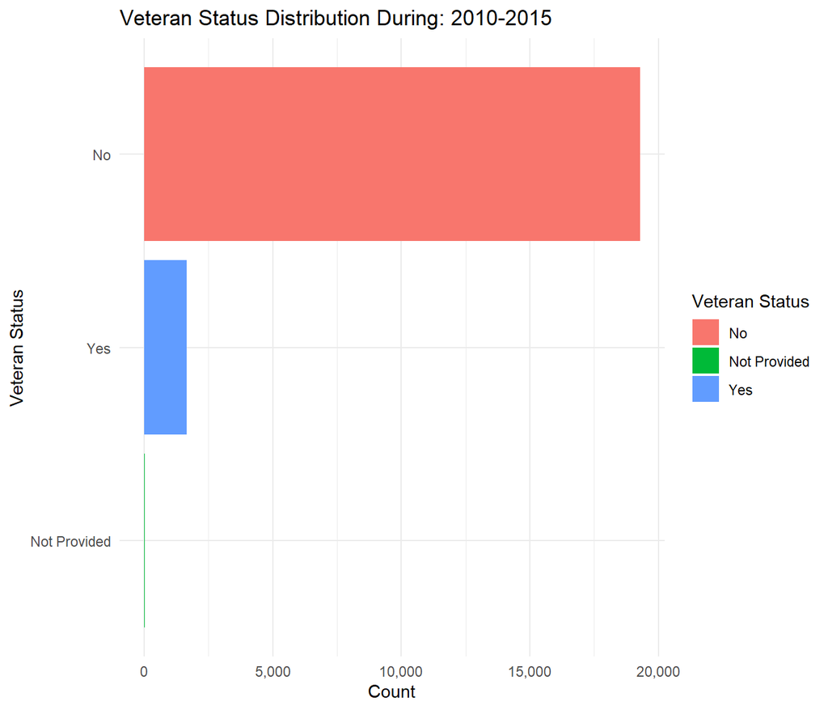

```r
entire_clean_filtered %>%
  count(VetStatInd) %>%
  arrange(desc(n)) %>%
  mutate(
    Count = scales::comma(n),
    Percent = scales::percent(n / sum(n))
  ) %>%
  ggplot( aes(x = reorder(VetStatInd, n), y = n, fill = VetStatInd)) +
  geom_bar(stat = "identity") +
  coord_flip() +
  labs(
    title = paste("Veteran Status Distribution During:", input),
    x = "Veteran Status",
    y = "Count"
  ) +
  theme_minimal()+
  scale_y_continuous(breaks = seq(0, 20000, by = 5000),
  labels = scales::comma) +
  scale_fill_discrete(name = "Veteran Status")
```

```r
entire_clean_filtered %>%
  count(VetStatInd) %>%
  arrange(desc(n)) %>%
  mutate(Count = scales::comma(n),
    Percent = scales::percent(n / sum(n))) %>%
    select(VetStatInd, Count, Percent) %>%
  kable(col.names = c("Veteran Status", "Count", "Percent"),
        caption = paste("Veteran Status Distribution During:", input)) %>%
  kable_styling(bootstrap_options = c("striped", "hover", "condensed"))
```

Veteran Status Distribution During: 2010-2015

| Veteran Status | Count | Percent |
| --- | --- | --- |
| No | 19,275 | 92.0% |
| Yes | 1,657 | 7.9% |
| Not Provided | 23 | 0.1% |

## Gender

The apprentice program seems to have a higher participation of males than females, which may be reinforced by the type of roles offered, and lack of support systems for female and other marginalized genders.

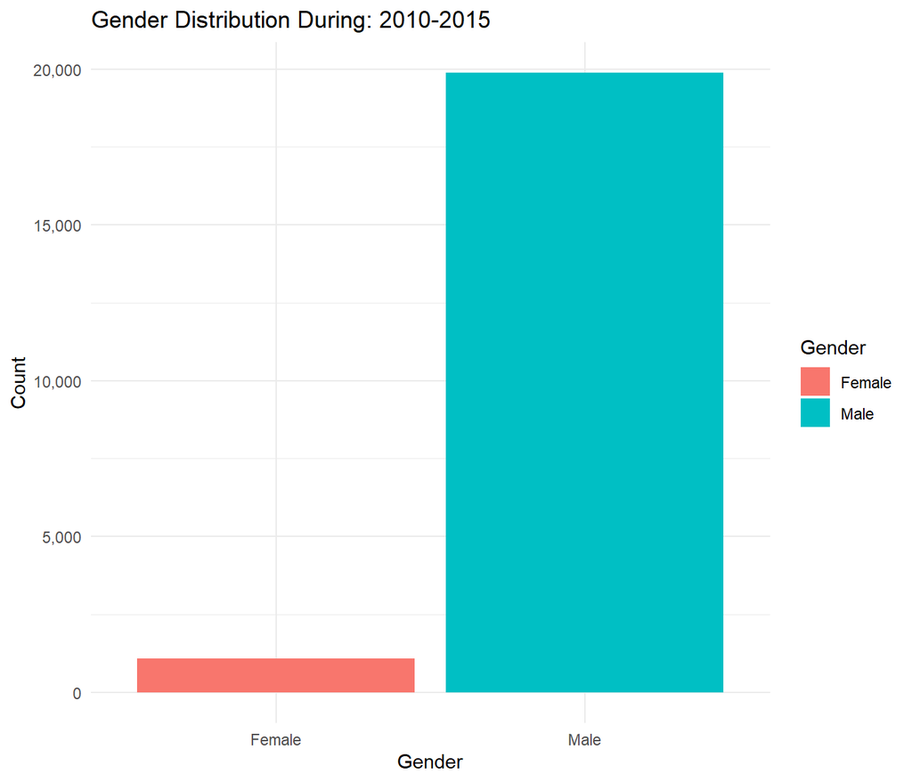

```r
entire_clean_filtered %>%
  count(Gender) %>%
  arrange(desc(n)) %>%
  mutate(
    Count = scales::comma(n),
    Percent = scales::percent(n / sum(n))
  ) %>%
  ggplot( aes(x = reorder(Gender, n),
              y = n,
              fill = Gender)) +
  geom_bar(stat = "identity") +
  labs(
    title = paste("Gender Distribution During:", input),
    x = "Gender",
    y = "Count"
  ) +
  scale_y_continuous(breaks = seq(0, 200000, by = 5000),
  labels = scales::comma) +
  theme_minimal()
```

```r
entire_clean_filtered %>%
  count(Gender) %>%
  arrange(desc(n)) %>%
  mutate(Count = scales::comma(n),
    Percent = scales::percent(n / sum(n))) %>%
    select(Gender, Count, Percent) %>%
  kable(col.names = c("Gender Status", "Count", "Percent"),
  caption = paste("Gender Status Distribution During:", input)) %>%
  kable_styling(bootstrap_options = c("striped", "hover", "condensed"))
```

Gender Status Distribution During: 2010-2015

| Gender Status | Count | Percent |
| --- | --- | --- |
| Male | 19,874 | 95% |
| Female | 1,081 | 5% |

## Race

The majority of participants identified as white, followed by participants identified as black or African-Americans.

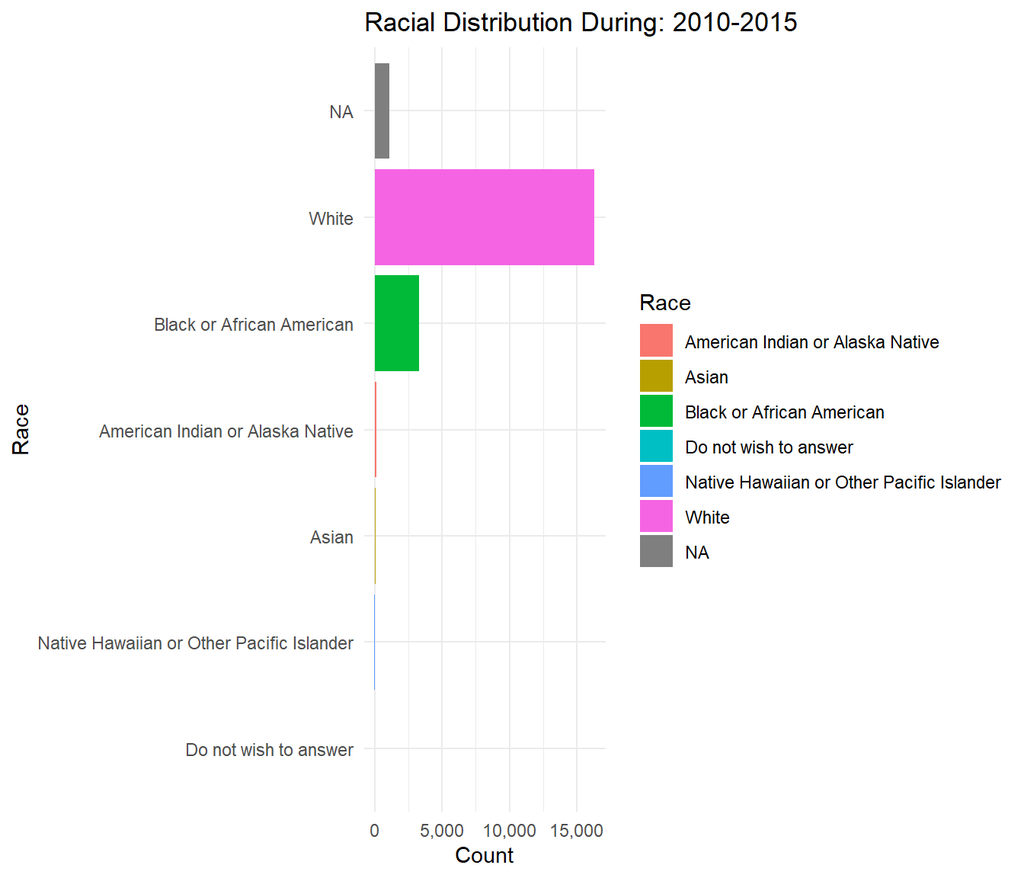

```r
entire_clean_filtered %>%
  count(Race) %>%
  arrange(desc(n)) %>%
  mutate(
    Count = scales::comma(n),
    Percent = scales::percent(n / sum(n))
  ) %>%
  ggplot( aes(x = reorder(Race, n),
              y = n,
              fill = Race)) +
  geom_bar(stat = "identity") +
  coord_flip() +
  labs(
    title = paste("Racial Distribution During:", input),
    x = "Race",
    y = "Count"
  ) +
  scale_y_continuous(breaks = seq(0, 15000, by = 5000),
  labels = scales::comma) +
  theme_minimal()
```

```r
entire_clean_filtered %>%
  count(Race) %>%
  arrange(desc(n)) %>%
  mutate(Count = scales::comma(n),
    Percent = scales::percent(n / sum(n))) %>%
    select(Race, Count, Percent) %>%
  kable(col.names = c("Race Status", "Count", "Percent"),
        caption = paste("Race Status Distribution During:", input)) %>%
  kable_styling(bootstrap_options = c("striped", "hover", "condensed"))
```

Race Status Distribution During: 2010-2015

| Race Status | Count | Percent |
| --- | --- | --- |
| White | 16,328 | 77.919% |
| Black or African American | 3,285 | 15.676% |
| NA | 1,100 | 5.249% |
| American Indian or Alaska Native | 118 | 0.563% |
| Asian | 71 | 0.339% |
| Native Hawaiian or Other Pacific Islander | 29 | 0.138% |
| Do not wish to answer | 24 | 0.115% |

## Disabled Status

The majority of applicants identified disabled status as “Not Provided” compared to identifying as disabled. This suggests that respondents view this metric on a very personal level to opt out of responding rather than indicate an affirmative or a negative response. This indicates that the participants may wish to keep this type of information private, or that there is a non-professional diagnosis that is wished to be expressed.

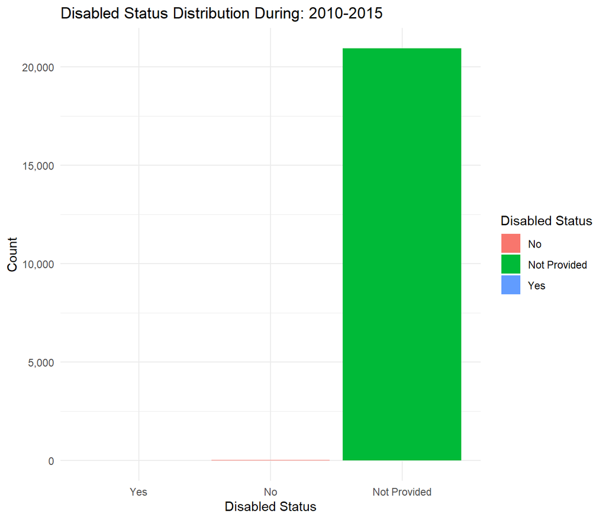

```r
entire_clean_filtered %>%
  count(Disabled) %>%
  arrange(desc(n)) %>%
  mutate(
    Count = scales::comma(n),
    Percent = scales::percent(n / sum(n))
  ) %>%
  ggplot( aes(x = reorder(Disabled, n),
              y = n,
              fill = Disabled)) +
  geom_bar(stat = "identity") +

  labs(
    title = paste("Disabled Status Distribution During:", input),
    x = "Disabled Status",
    y = "Count"
  ) +
  scale_y_continuous(breaks = seq(0, 20000, by = 5000),
  labels = scales::comma) +
  theme_minimal() +
  scale_fill_discrete(name = "Disabled Status")
```

```r
entire_clean_filtered %>%
  count(Disabled) %>%
  arrange(desc(n)) %>%
  mutate(Count = scales::comma(n),
    Percent = scales::percent(n / sum(n))) %>%
    select(Disabled, Count, Percent) %>%
  kable(col.names = c("Disabled Status", "Count", "Percent"),
  caption = paste("Disabled Status Distribution During:", input)) %>%
  kable_styling(bootstrap_options = c("striped", "hover", "condensed"))
```

Disabled Status Distribution During: 2010-2015

| Disabled Status | Count | Percent |
| --- | --- | --- |
| Not Provided | 20,935 | 99.905% |
| No | 17 | 0.081% |
| Yes | 3 | 0.014% |

## Education

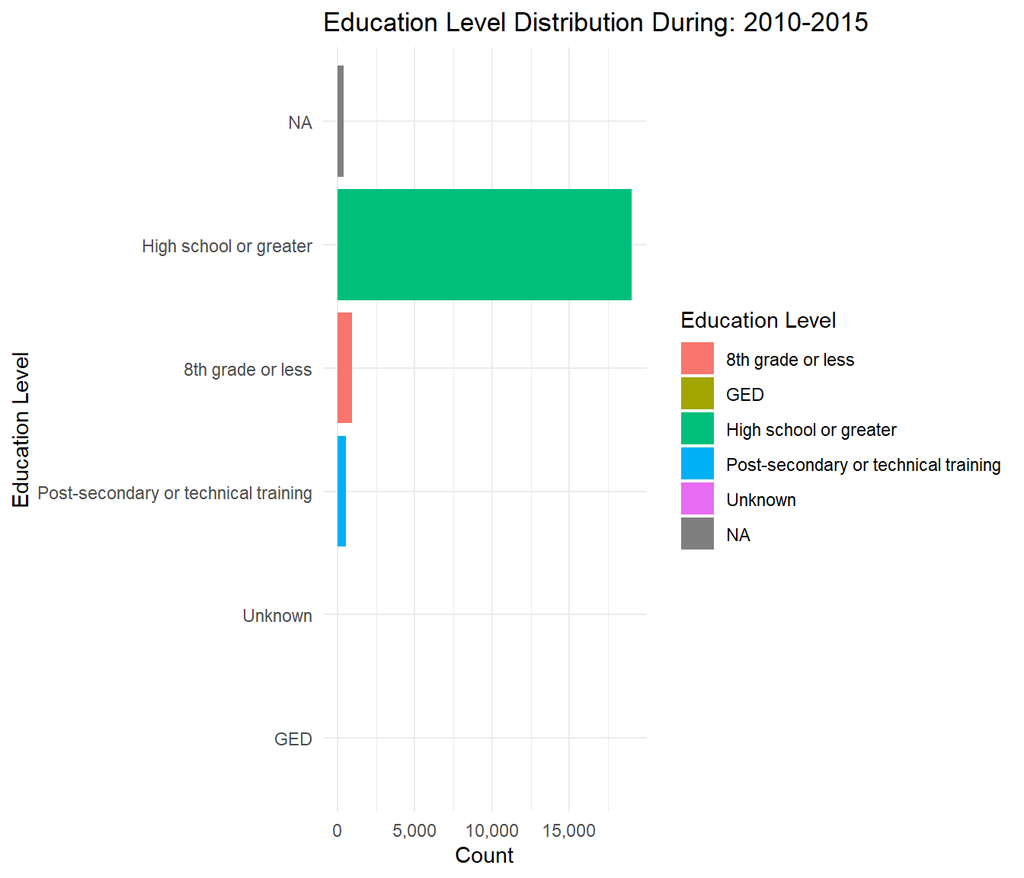

```r
entire_clean_filtered %>%
  count(education) %>%
  arrange(desc(n)) %>%
  mutate(
    Count = scales::comma(n),
    Percent = scales::percent(n / sum(n))
  ) %>%
  ggplot( aes(x = reorder(education, n),
              y = n,
              fill = education)) +
  geom_bar(stat = "identity") +
  coord_flip() +
  labs(
    title = paste("Education Level Distribution During:", input),
    x = "Education Level",
    y = "Count"
  ) +
  scale_y_continuous(breaks = seq(0, 15000, by = 5000),
  labels = scales::comma) +
  theme_minimal() +
  scale_fill_discrete(name = "Education Level")
```

```r
entire_clean_filtered %>%
  count(education) %>%
  arrange(desc(n)) %>%
  mutate(Count = scales::comma(n),
    Percent = scales::percent(n / sum(n))) %>%
    select(education, Count, Percent) %>%
  kable(col.names = c("Education Status", "Count", "Percent"),
  caption = paste("Education Status Distribution During:", input)) %>%
  kable_styling(bootstrap_options = c("striped", "hover", "condensed"))
```

Education Status Distribution During: 2010-2015

| Education Status | Count | Percent |
| --- | --- | --- |
| High school or greater | 19,046 | 90.8900% |
| 8th grade or less | 940 | 4.4858% |
| Post-secondary or technical training | 541 | 2.5817% |
| NA | 417 | 1.9900% |
| Unknown | 6 | 0.0286% |
| GED | 5 | 0.0239% |

## Apprentrice Starting Age Bins

The majority of applicants identified between the ages of 20-29, followed by age group of 30-39. Ages were floored at age 14, and capped at age 90 to account for outliers.

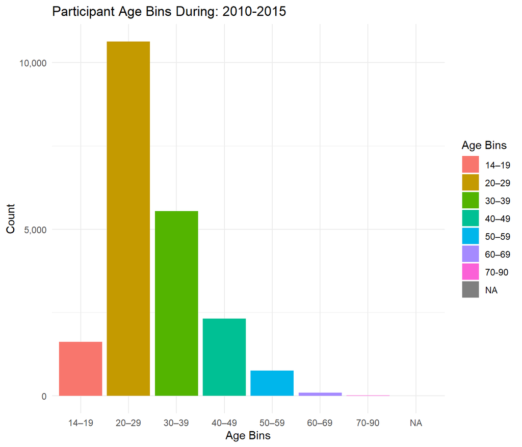

```r
entire_clean_filtered %>%
  count(age_bin) %>%
  mutate(
    Count = scales::comma(n),
    Percent = scales::percent(n / sum(n))
  ) %>%
  ggplot( aes(x = age_bin,
              y = n,
              fill = age_bin)) +
  geom_bar(stat = "identity") +
  labs(
    title = paste("Participant Age Bins During:", input),
    x = "Age Bins",
    y = "Count") +
  scale_y_continuous(breaks = seq(0, 150000, by = 5000),
  labels = scales::comma) +
  theme_minimal() +
  scale_fill_discrete(name = "Age Bins")
```

```r
entire_clean_filtered %>%
  count(age_bin) %>%
  mutate(
    Count = scales::comma(n),
    Percent = scales::percent(n / sum(n))
  ) %>%
  select(age_bin, Count, Percent) %>%
  kable(
    col.names = c("Age Bins At Start of Program", "Count", "Percent"),
    caption = paste("Age Bins At Start of Program  Distribution During:", input)) %>%
  kable_styling(bootstrap_options = c("striped", "hover", "condensed"))
```

Age Bins At Start of Program Distribution During: 2010-2015

| Age Bins At Start of Program | Count | Percent |
| --- | --- | --- |
| 14–19 | 1,613 | 7.697% |
| 20–29 | 10,629 | 50.723% |
| 30–39 | 5,545 | 26.461% |
| 40–49 | 2,311 | 11.028% |
| 50–59 | 754 | 3.598% |
| 60–69 | 91 | 0.434% |
| 70-90 | 10 | 0.048% |
| NA | 2 | 0.010% |

# **Program Attributes**

## Apprentice Status

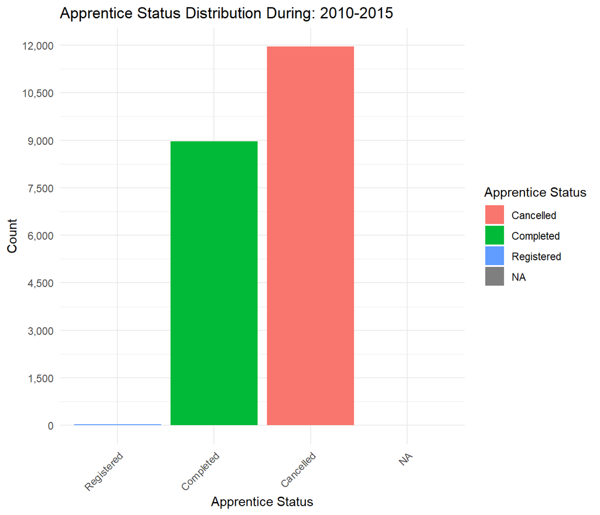

```r
entire_clean_filtered %>%
  count(apprStatus) %>%
  arrange(desc(n)) %>%
  mutate(
    Count = scales::comma(n),
    Percent = scales::percent(n / sum(n))
  ) %>%
  ggplot( aes(x = reorder(apprStatus, n),
              y = n,
              fill = apprStatus)) +
  geom_bar(stat = "identity") +
  labs(
    title = paste("Apprentice Status Distribution During:", input),
    x = "Apprentice Status",
    y = "Count") +
  scale_y_continuous(breaks = seq(0, 15000, by = 1500),
  labels = scales::comma) +
  theme_minimal() +
  scale_fill_discrete(name = "Apprentice Status")+
  theme(axis.text.x = element_text(angle = 45, hjust = 1))
```

```r
entire_clean_filtered %>%
  count(apprStatus) %>%
  mutate(
  Count = scales::comma(n),
  Percent = scales::percent(n / sum(n))) %>%
  select(apprStatus, Count, Percent) %>%
  kable(
  col.names = c("Program Status", "Count", "Percent"),
  caption = paste("Program Status During:", input)) %>%
  kable_styling(bootstrap_options = c("striped", "hover", "condensed"))
```

Program Status During: 2010-2015

| Program Status | Count | Percent |
| --- | --- | --- |
| Cancelled | 11,955 | 57.05% |
| Completed | 8,969 | 42.80% |
| Registered | 30 | 0.14% |
| NA | 1 | 0.00% |

## Start and Exit Wages

```r
chi_wage <- entire_clean_filtered[
  entire_clean_filtered$st_wage_bin %in% c("Below $7.25", "$7.25–$14", "$15–$19", "$20–$29") &
  entire_clean_filtered$end_wage_bin %in% c("Below $7.25", "$7.25–$14", "$15–$19", "$20–$29"),
]

wage_table <- table(chi_wage$st_wage_bin, chi_wage$end_wage_bin)

wage_table_clean <- wage_table[rowSums(wage_table) > 0, colSums(wage_table) > 0]

chi_wage_results <- chisq.test(wage_table_clean)
```

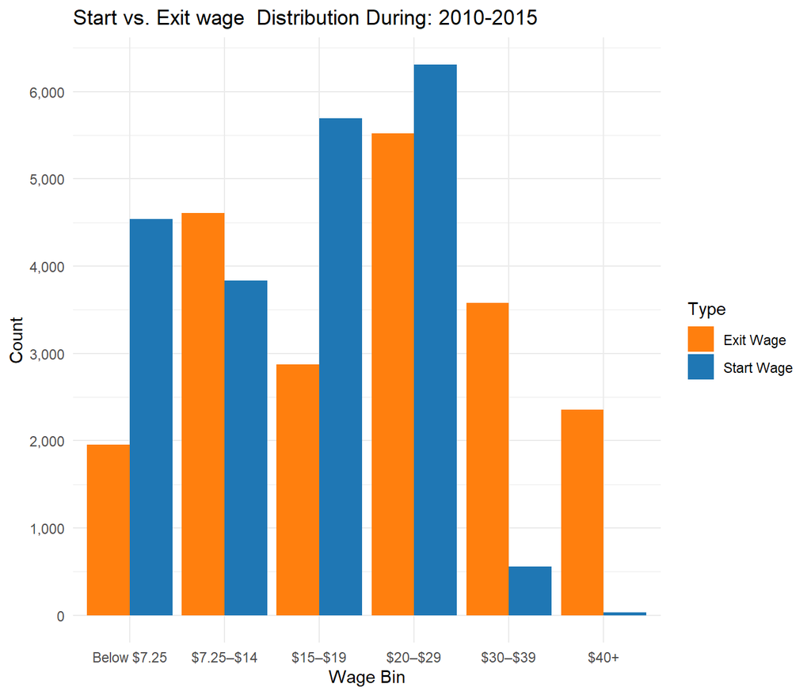

```r
start_tab <- table(entire_clean_filtered$st_wage_bin)
end_tab <- table(entire_clean_filtered$end_wage_bin)

start_df <- as.data.frame(start_tab)
colnames(start_df) <- c("Wage_Bin", "Count")
start_df$Type <- "Start Wage"

end_df <- as.data.frame(end_tab)
colnames(end_df) <- c("Wage_Bin", "Count")
end_df$Type <- "Exit Wage "

wage_plot_df <- rbind(start_df, end_df)

ggplot(wage_plot_df, aes(x = Wage_Bin, y = Count, fill = Type)) +
  geom_bar(stat = "identity", position = "dodge") +
  labs(
    title = paste("Start vs. Exit wage  Distribution During:", input),
    x = "Wage Bin",
    y = "Count") +
  scale_fill_manual(values = c("Start Wage" = "#1f77b4", "Exit Wage " = "#ff7f0e")) +
  theme_minimal() +
  scale_y_continuous(breaks = seq(0, 20000, by = 1000),
  labels = scales::comma) +
  theme(axis.text.x = element_text(angle = 0, hjust = 0.5))
```

```r
paired_df <- entire_clean_filtered %>%
  filter(!is.na(st_wage_clean), !is.na(end_wage_clean)) %>%
  select(psId, st_wage_clean, end_wage_clean)

wilcox_results <- wilcox.test(paired_df$end_wage_clean, paired_df$st_wage_clean, paired = TRUE)
median_result <- median(paired_df$end_wage_clean - paired_df$st_wage_clean)
```

```r
entire_clean_filtered %>%
  count(st_wage_bin) %>%
  mutate(
    Count = scales::comma(n),
    Percent = scales::percent(n / sum(n))) %>%
  select(st_wage_bin, Count, Percent) %>%
  kable(
    col.names = c("Start Wage", "Count", "Percent"),
    caption = paste("Start Wage Distribution During:", input)) %>%
  kable_styling(bootstrap_options = c("striped", "hover", "condensed"))
```

Start Wage Distribution During: 2010-2015

| Start Wage | Count | Percent |
| --- | --- | --- |
| Below $7.25 | 4,536 | 21.6% |
| $7.25–$14 | 3,831 | 18.3% |
| $15–$19 | 5,692 | 27.2% |
| $20–$29 | 6,306 | 30.1% |
| $30–$39 | 557 | 2.7% |
| $40+ | 33 | 0.2% |

```r
entire_clean_filtered %>%
  count(end_wage_bin) %>%
  mutate(
    Count = scales::comma(n),
    Percent = scales::percent(n / sum(n))
  ) %>%
  select(end_wage_bin, Count, Percent) %>%
  kable(
    col.names = c("Exit Wage", "Count", "Percent"),
    caption = paste("Exit Wage Distribution During:", input) ) %>%
  kable_styling(bootstrap_options = c("striped", "hover", "condensed"))
```

Exit Wage Distribution During: 2010-2015

| Exit Wage | Count | Percent |
| --- | --- | --- |
| Below $7.25 | 1,953 | 9.3% |
| $7.25–$14 | 4,610 | 22.0% |
| $15–$19 | 2,875 | 13.7% |
| $20–$29 | 5,523 | 26.4% |
| $30–$39 | 3,581 | 17.1% |
| $40+ | 2,352 | 11.2% |
| NA | 61 | 0.3% |

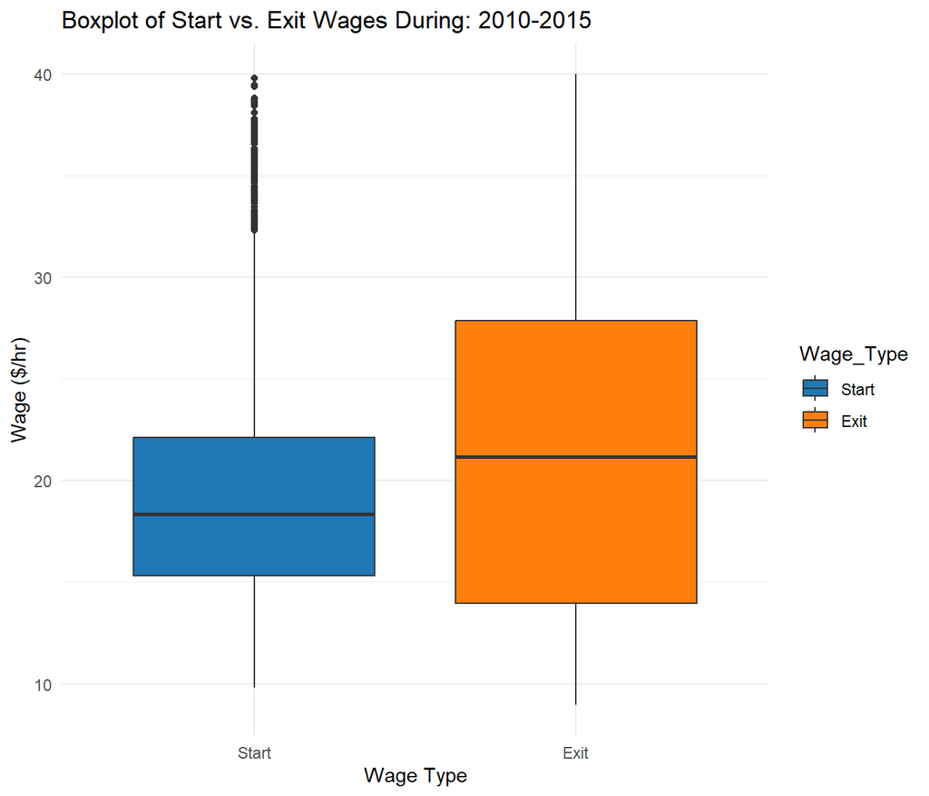

```r
wage_type <- c(rep("Start", sum(!is.na(entire_clean_filtered$st_wage_clean))),
               rep("Exit", sum(!is.na(entire_clean_filtered$end_wage_clean))))

wages <- c(na.omit(entire_clean_filtered$st_wage_clean),
           na.omit(entire_clean_filtered$end_wage_clean))

box_df <- data.frame(Wage_Type = factor(wage_type, levels = c("Start", "Exit")),
                     Wage = wages)

ggplot(box_df,
  aes(x = Wage_Type,
  y = Wage,
  fill = Wage_Type)) +
  geom_boxplot() +
  scale_fill_manual(values = c("Start" = "#1f77b4", "Exit" = "#ff7f0e")) +
  labs(title = paste("Boxplot of Start vs. Exit Wages During:", input),
       x = "Wage Type",
       y = "Wage ($/hr)") +
  theme_minimal()
```

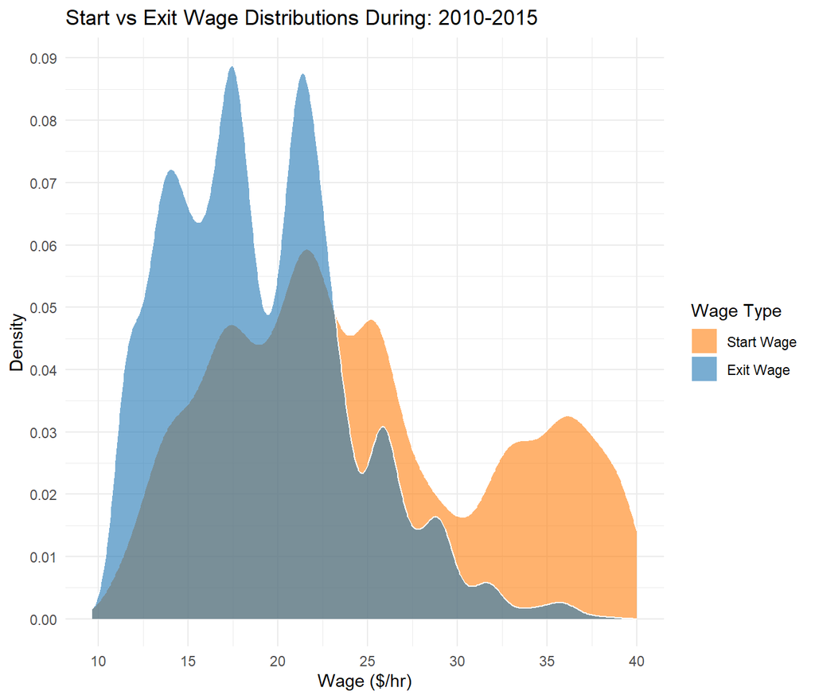

```r
wage_long <- paired_df %>%
  select(st_wage_clean, end_wage_clean) %>%
  tidyr::pivot_longer(cols = everything(), names_to = "wage_type", values_to = "wage")

ggplot(wage_long, aes(x = wage, fill = wage_type)) +
  geom_density(alpha = 0.6, color = "white") +
  scale_fill_manual(values = c("st_wage_clean" = "#1f77b4", "end_wage_clean" = "#ff7f0e"),
                    labels = c("Start Wage", "Exit Wage")) +
  labs(title = paste("Start vs Exit Wage Distributions During:", input),
       x = "Wage ($/hr)",
       y = "Density",
       fill = "Wage Type") +
  theme_minimal() +
  scale_y_continuous(breaks = seq(0, 1, by = .01),
  labels = scales::comma) +
  scale_x_continuous(breaks = seq(0, 40, by = 5))
```

## Program Industries

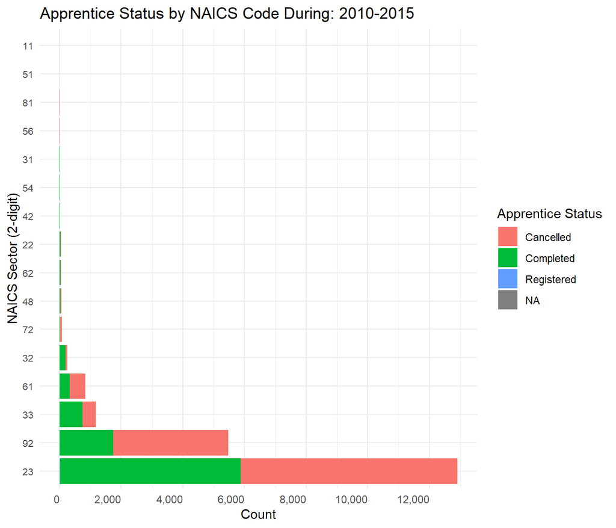

```r
entire_clean_filtered %>%
  ggplot( aes(x = fct_infreq(as.factor(short_naics)),
              fill = apprStatus)) +
  geom_bar(position = "stack") +
  labs(
    title = paste("Apprentice Status by NAICS Code During:", input),
    x = "NAICS Sector (2-digit)",
    y = "Count",
    fill = "Apprentice Status") +
  coord_flip()+
  theme_minimal() +
  scale_y_continuous(breaks = seq(0, 30000, by = 2000),
                    labels = scales::comma) +
  theme(axis.text.x = element_text(angle = 0, hjust = 1),
        axis.text.y = element_text(size = 8))
```

Overall, most apprentices are geared for select sectors such as Construction (NAICS 23), followed by Public Administration (NAICS 92) and Manufacturing (NAICS 31–33). The program is really construction, and public administration heavy. Construction is a job role typically associated as male gender role, which is reinforced in the disproprotionate male apprentices. Female labor participation is largely not represented in the apprenticeship program which could be endogenously reinforced.

```r
entire_clean_filtered %>%
  count(short_naics, `2022 NAICS US Title`) %>%
  mutate(
    Count = scales::comma(n),
    Percent = scales::percent(n / sum(n))) %>%
  arrange(desc(n)) %>%
  select(`2022 NAICS US Title`, short_naics, Count, Percent) %>%
  kable(
    col.names = c('2022 NAICS Title', "NAICS Code (3-digit)", "Count", "Percent"),
    caption = paste("Distribution of Apprentices by NAICS Code During:", input) ) %>%
  kable_styling(bootstrap_options = c("striped", "hover", "condensed"))
```

Distribution of Apprentices by NAICS Code During: 2010-2015

[output not shown]

## Program County Location

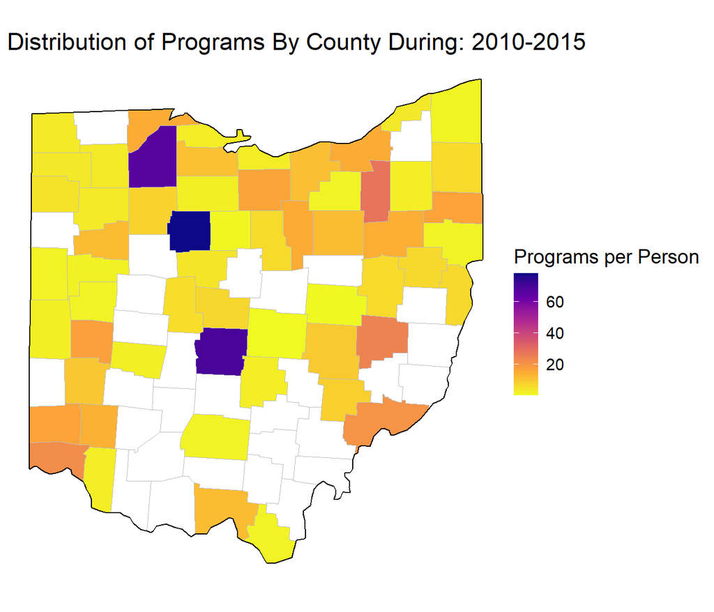

```r
usa <- map_data("usa")
states <- map_data("state")
counties <- map_data('county')

counties_v <- counties[counties$region == 'ohio',  ]
states_v <- states[states$region == 'ohio', ]

#get county population
oh_pop <- countypop %>%
  filter(abbr == "OH") %>%
  mutate(subregion = tolower(county)) #population from 2022

programs_by_county <- entire_clean_filtered %>%
  group_by(County) %>%
  summarise(prog_count = n())

programs_by_county <- programs_by_county %>%
  left_join(oh_pop, by = c('County' = 'county')) %>%
  mutate(prog_per_capita = (prog_count / pop_2022) * 10000)

programs_by_county$County <- tolower(programs_by_county$County)
programs_by_county$subregion <- sapply(strsplit(programs_by_county$County, " "), `[`, 1)

merge_OH_data <- counties_v %>%
  left_join(programs_by_county, by = c("subregion" = "subregion"))

merge_OH_data %>%
  ggplot() +
    geom_polygon(
      aes(x = long,
          y = lat,
          group = group,
          fill = prog_per_capita),
        color = "gray",
        size = 0.3) +
    geom_polygon(
      data = states_v,
      aes(x = long,
          y = lat,
          group = group),
        fill = NA,
        color = "black",
        size = 0.5) +
    scale_fill_viridis_c(
      option = "plasma",
      na.value = "white",
      direction = -1,
      name = "Programs per Person") +
    coord_fixed(1.3) +
    theme_void() +
    labs(title = paste('Distribution of Programs By County During:', input))+
    theme(
      text = element_text(size = 14),
      plot.margin = margin(5, 10, 5, 5),
      legend.position = "right"
    )
```

```r
entire_clean_filtered %>%
  count(County, progCity) %>%
  mutate(
    Count = scales::comma(n),
    Percent = scales::percent(n / sum(n))
  ) %>%
  arrange(desc(n)) %>%
  slice_max(n, n = 10) %>%
  select(County, progCity, Count, Percent) %>%
  kable(
    col.names = c("Ohio County", "City/Metro Area", "Count", "Percent"),
    caption = paste("Distribution of Apprentices by County and Nearest Metro Area During:", input) ) %>%
  kable_styling(bootstrap_options = c("striped", "hover", "condensed"))
```

Distribution of Apprentices by County and Nearest Metro Area During: 2010-2015

| Ohio County | City/Metro Area | Count | Percent |
| --- | --- | --- | --- |
| Franklin County | COLUMBUS | 8,342 | 39.8091% |
| Hamilton County | CINCINNATI | 1,715 | 8.1842% |
| Summit County | RICHFIELD | 1,151 | 5.4927% |
| Franklin County | WESTERVILLE | 807 | 3.8511% |
| Cuyahoga County | CLEVELAND | 723 | 3.4503% |
| Wood County | ROSSFORD | 688 | 3.2832% |
| Butler County | MONROE | 519 | 2.4767% |
| Lucas County | TOLEDO | 476 | 2.2715% |
| Montgomery County | DAYTON | 472 | 2.2524% |
| Cuyahoga County | STRONGSVILLE | 383 | 1.8277% |

Next Steps would be to map county level information to assess how individuals in their county of residence, and their county of employment interact and are supported in the program. This geographic information would help identify areas that have strong pipelines of participants in the apprentice program. Other steps include learning more on why applicants leave the apprenticeship program as noted in their free response field. Since this field is free response, I suggest some light natural language processing (NLP) analysis to be performed such as token analysis of keywords. This would also elicit an insider’s view of the program in a structured way. As for the program itself, marketing strategies could be implemented to expand the demographics of participants, and on the employer-side additional variety of job roles would offer more incentives for participants. Employers would likely also need an incentive to offer a program. Also monitoring of the program is recommended as well as developing structured resources for apprentices and employers for mutual success.